# Census analysis

Gray Collins

2025-10-17

```
##
## left_join: added 21 columns (pop_2000, pop_2001, pop_2002, pop_2003, pop_2004, …)
##            > rows only in nhood_routes   3
##            > rows only in nhood_pop    ( 0)
##            > matched rows               65
##            >                           ====
##            > rows total                 68
```

# Maps

## Taxi routes & population, by neighborhood

```
## ℹ tmap mode set to "plot".
```

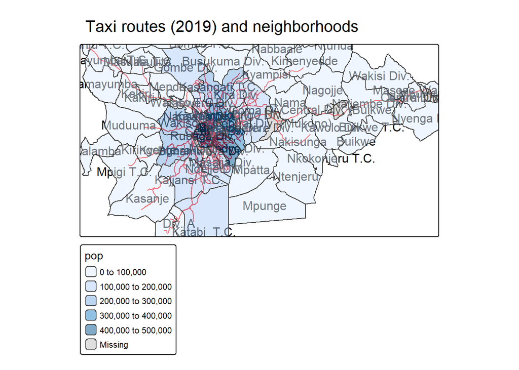

## Population

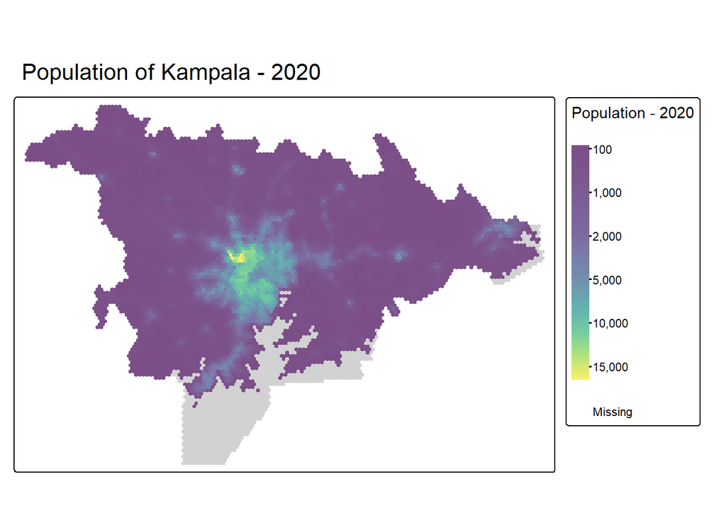

## Percent change in population

```
## [tm_polygons()] Argument `component.autoscale` unknown.
## Variable(s) "fill" contains positive and negative values, so midpoint is set to 0. Set midpoint = NA to show the full range of visual values.
```

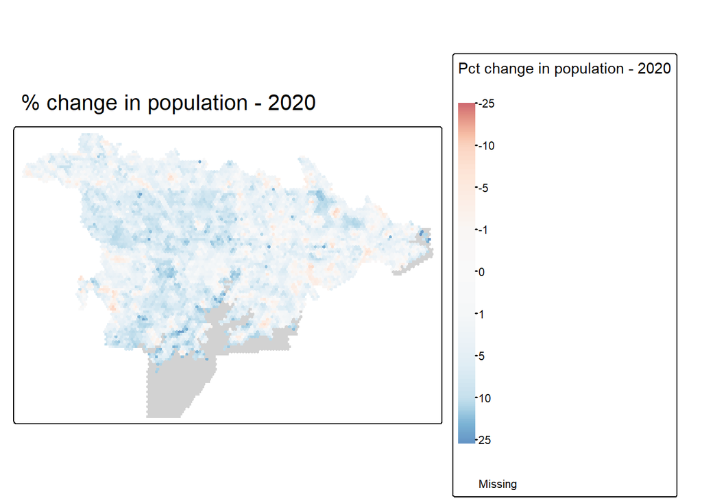

# Plots

## Route growth versus population growth

It seems like there is a logarithmically shaped relationship between population and route growth in neighborhoods with smaller populations. But for neighborhoods with larger populations, this relationship seems to take a different shape.

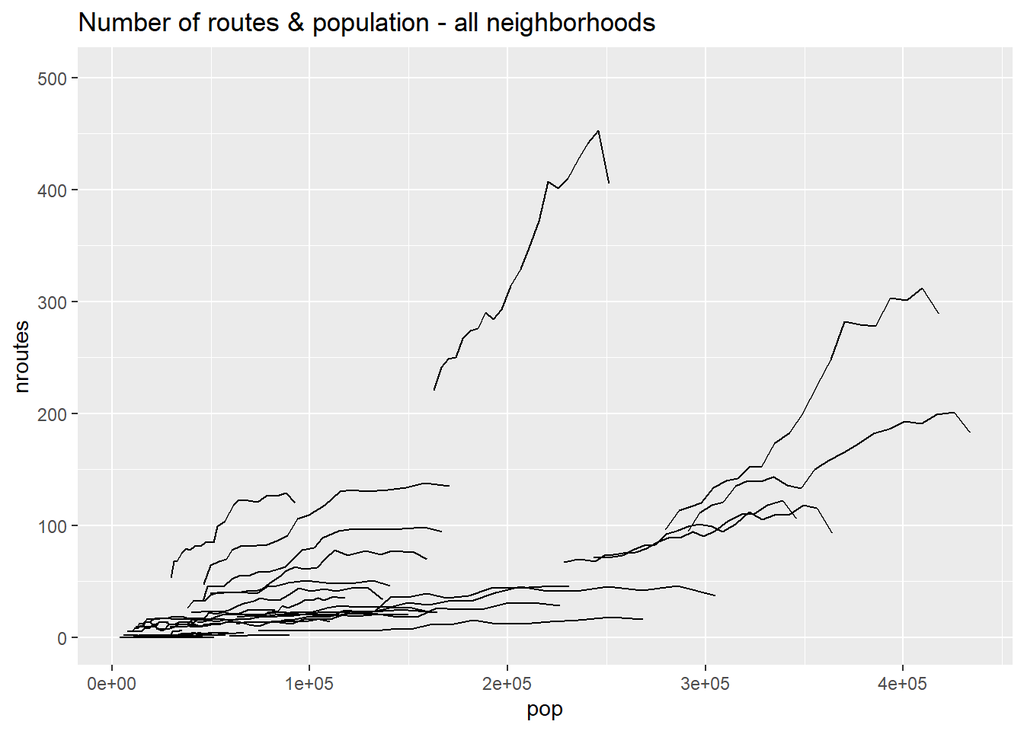

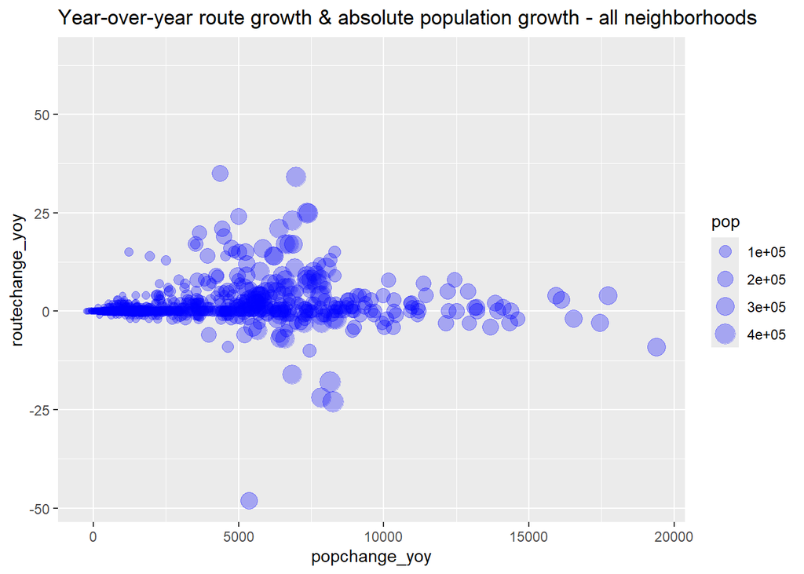

## Population change (neighborhood-level, year-over-year)

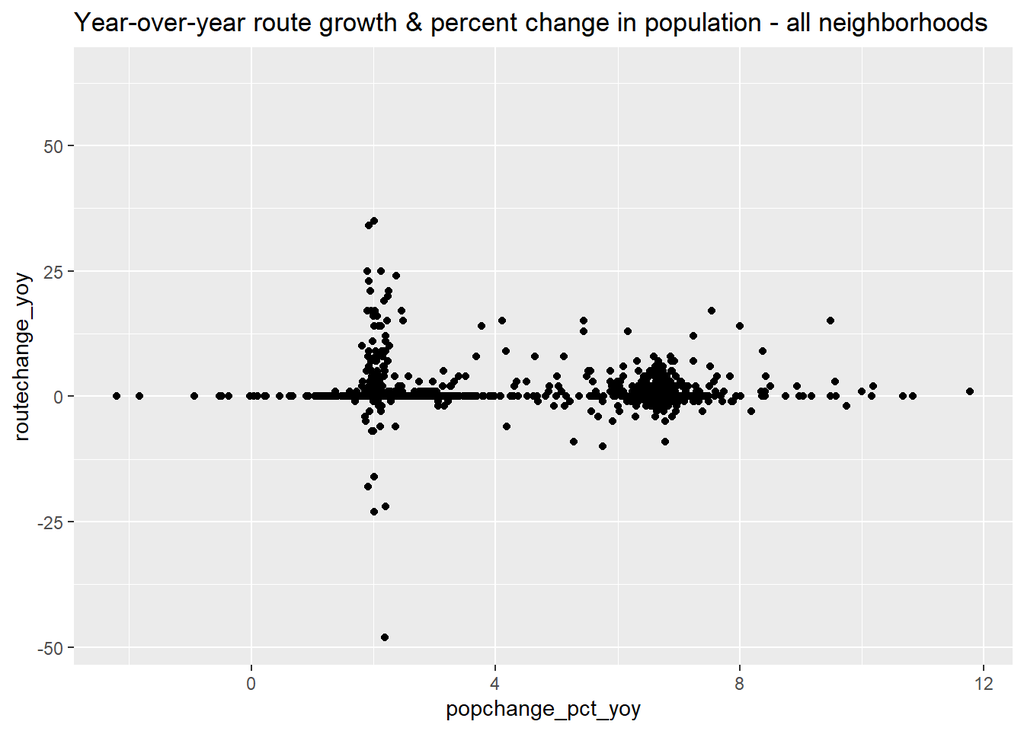

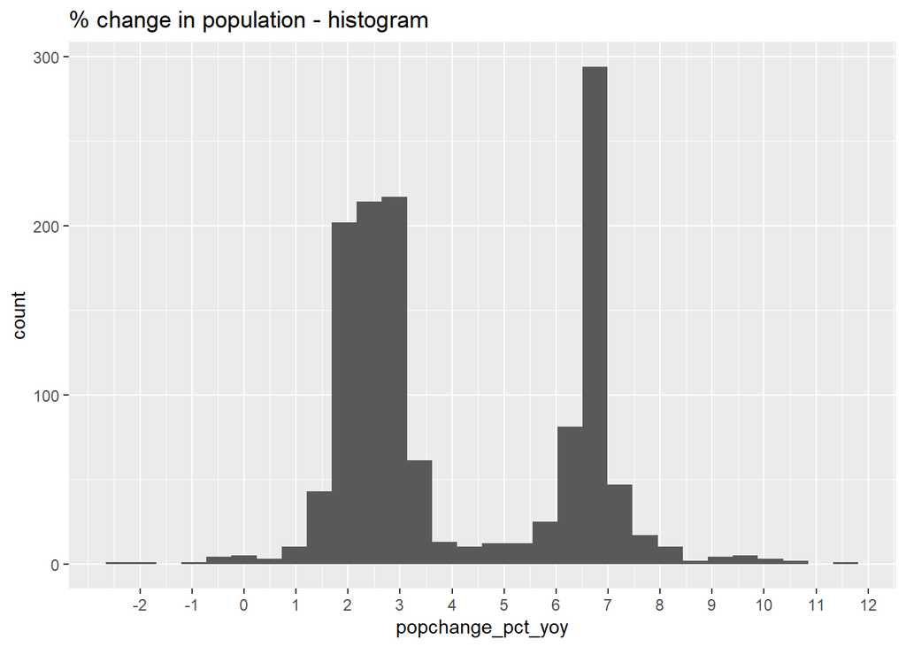

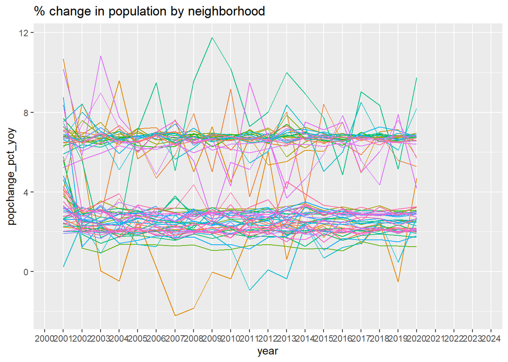

Below compares neighborhood X year combinations with 0 taxi routes to neighborhood X year combinations with any routes.

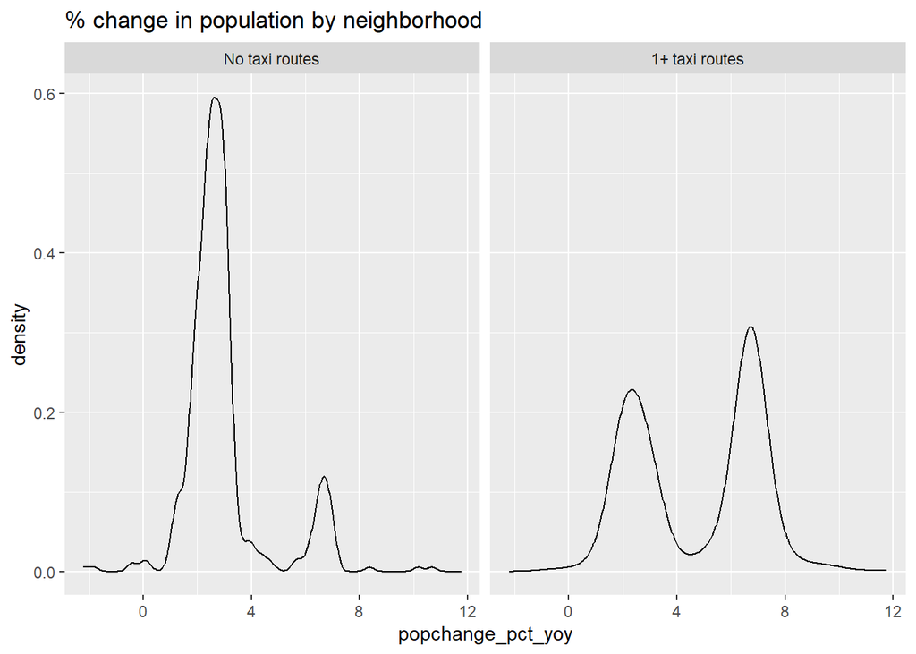

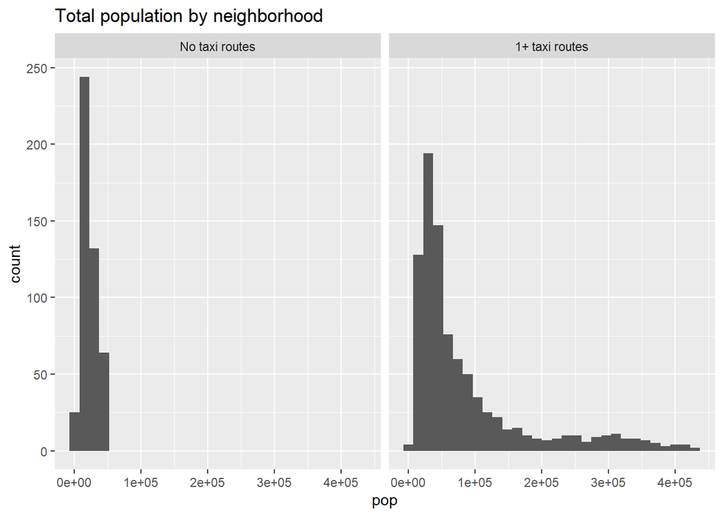

Log-population by neighborhood:

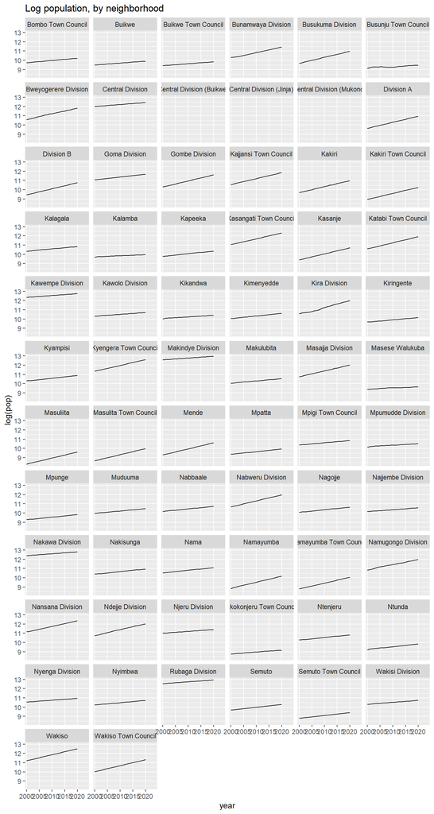

# Analysis

- Look among gridcells which are similar in population, in the ?th percentile of gridcells (find a reasonable cut point judging by population data).
- Identify which gridcells “earned” service (based on population) and those which didn’t (those with low population, but got a route anyway).
- Service indicator: Binary, whether a gridcell has routes going through it or not
- Diff in means (population) between these at different time intervals in future
  - Time horizon: test several
- Diff: between corridors which got a route and those which didnt

## Define reference year

IMPORTANT: The code below calculates differences in population and route coverage relative to this reference year; change it before rerunning the below analysis

## Find population cutpoint

First create an indicator for whether a route was added

```
## Simple feature collection with 5 features and 2 fields
## Geometry type: MULTIPOLYGON
## Dimension:     XY
## Bounding box:  xmin: 390243.9 ymin: 9983413 xmax: 532743.9 ymax: 10082430
## Projected CRS: WGS 84 / UTM zone 36S
## # A tibble: 5 × 3
##   service_status_l                         n                            geometry
##   <fct>                                <int>                  <MULTIPOLYGON [m]>
## 1 [0] No routes in 2019                 6602 (((410243.9 10022384, 410743.9 100…
## 2 [2] Served 2019, unchanged from 2018   698 (((431243.9 10011414, 431243.9 100…
## 3 [1] Newly served in 2019                17 (((436243.9 10025848, 436743.9 100…
## 4 [3] Served 2019, increase from 2018    188 (((440743.9 10007084, 440743.9 100…
## 5 [4] Served 2019, decrease from 2018     35 (((447743.9 10026137, 448243.9 100…
```

Density plot: Population in served vs. non-served gridcells (reference year: 2019). The second plot (showing population in only those gridcells with any changes at all) doesn’t seem to suggest a clear population threshold at which a gridcell “earns” route service. Among those [1] newly served in 2019, there are too few observations to tell a cutoff; if there was any cutoff, perhaps it’d be pop=2500, but it’s counter-intuitive that most gridcells are below that threshold and only n=2 are above it. Perhaps among routes with [3] increased service relative to 2018, the distribution seems almost bimodal and pop=7500 could be a cutoff for increasing service. But this doesn’t explain the emergence of routes in previously unserved gridcells.

These plots + the table above show there are very few gridcells with any service changes whatsoever.

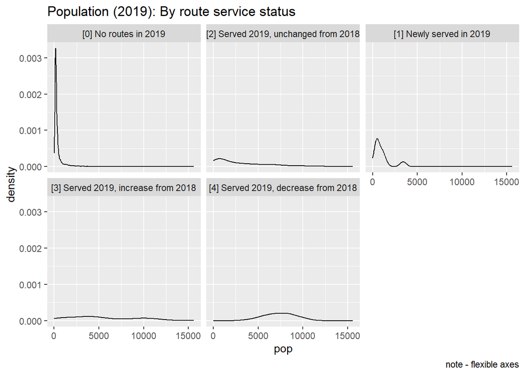

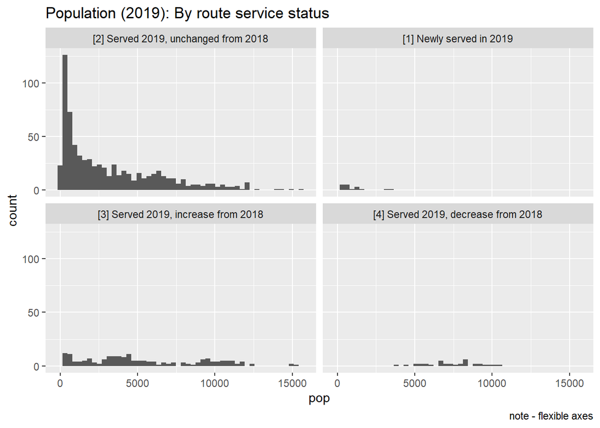

## Visualize new service corridors

Since there are so few gridcells where new service was added, can we try to classify them in another way–namely, is it visually apparent which transit corridor they are part of?

For the year 2019, there are a few clearly visible corridor additions: - In the West, Wakiso neighborhood, two routes divert to Kigoma, and another continues past Bukasa along Sentema Road. - To the Southwest, in Kyengera Town council, a new route from Kisenyi-Gwanda branches south from Kampala-Masaka Road and continues just across the Entebbe border via Busembe and Nanziga - In the South, a new route to Entebbe operates along the Kampala-Entebbe Expressway (which was opened in 2018), adding new service to several previously unserved gridcells in Kyengera and Kajjansi. - There are other, minor additions to routes that typically don’t result in a previously unserved gridcell getting service.

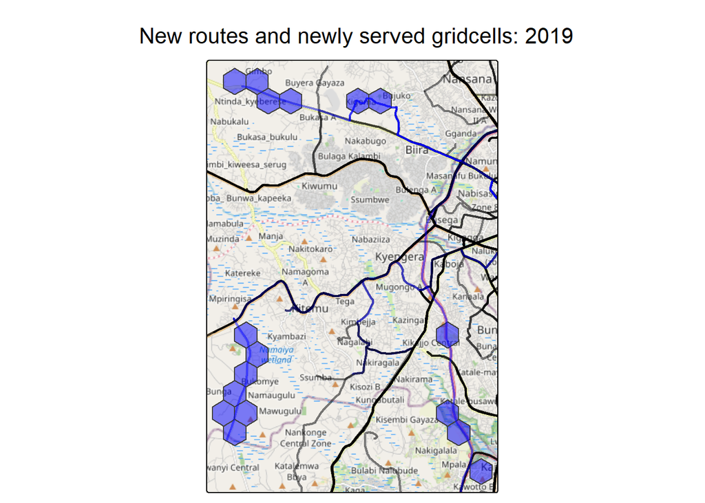

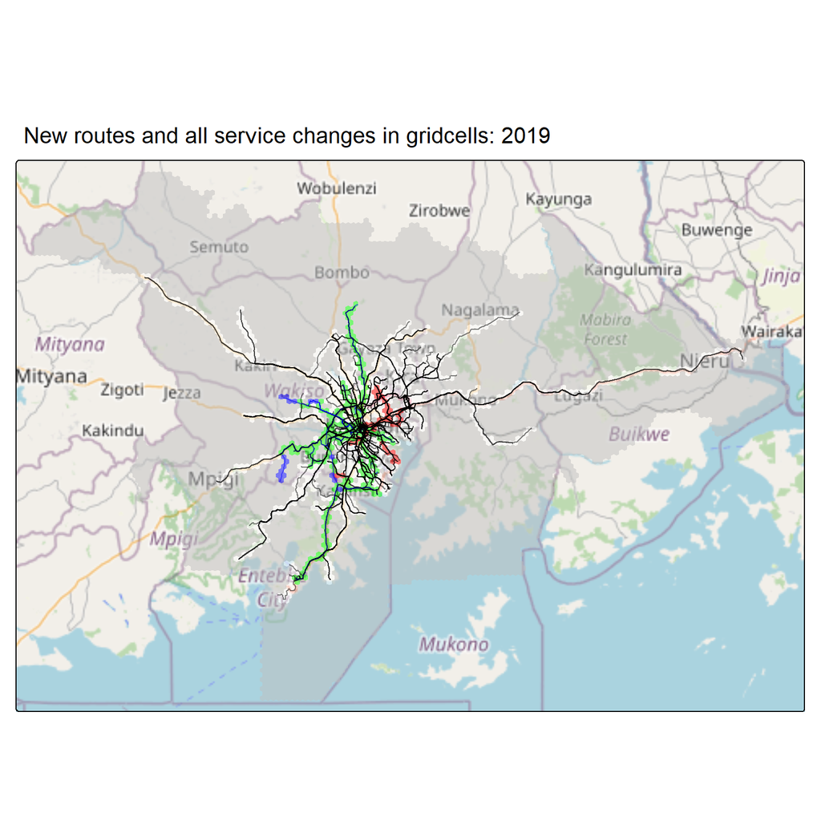

## Compare for other years

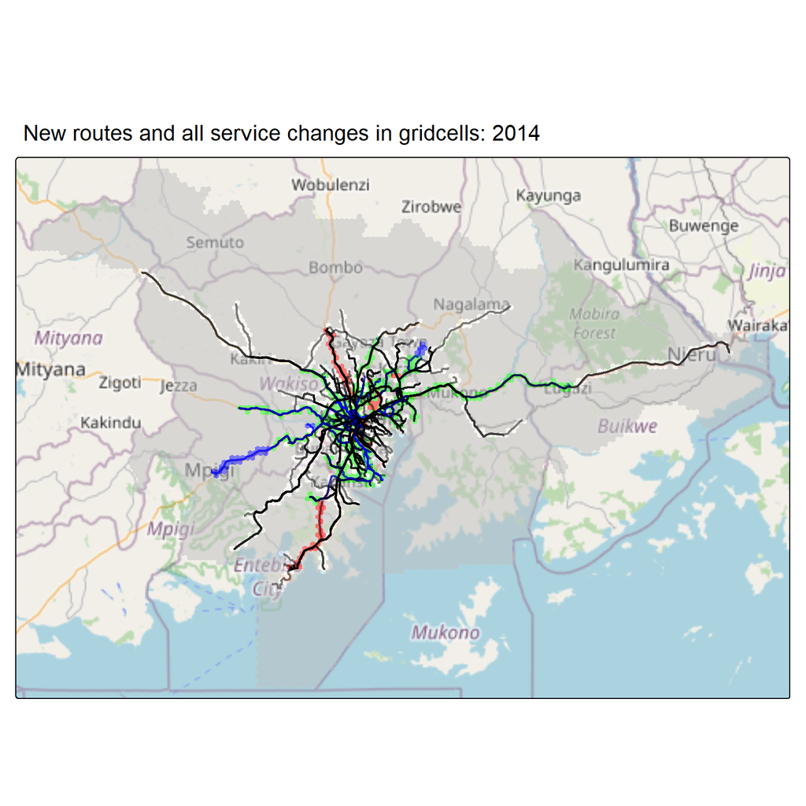

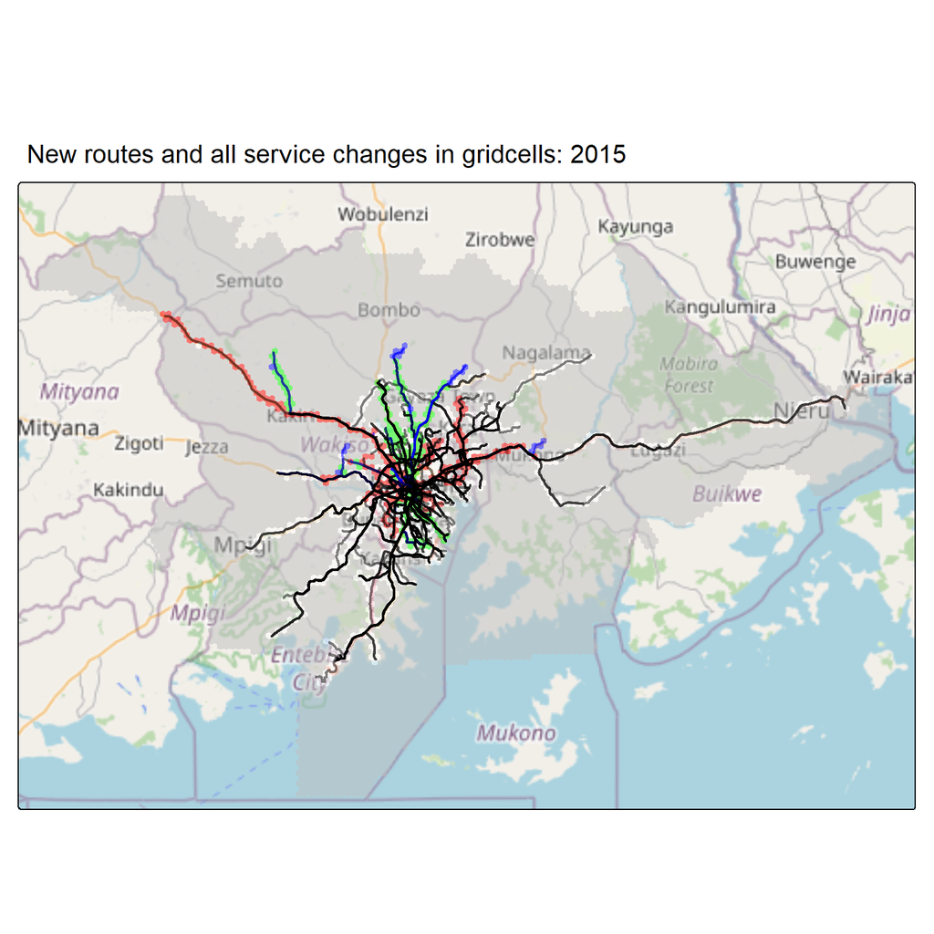

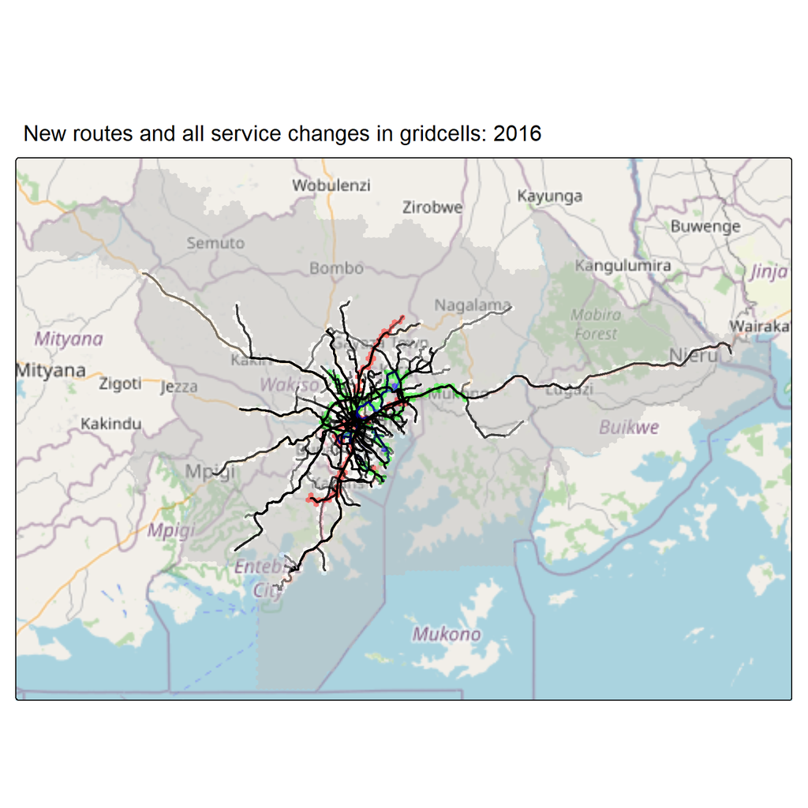

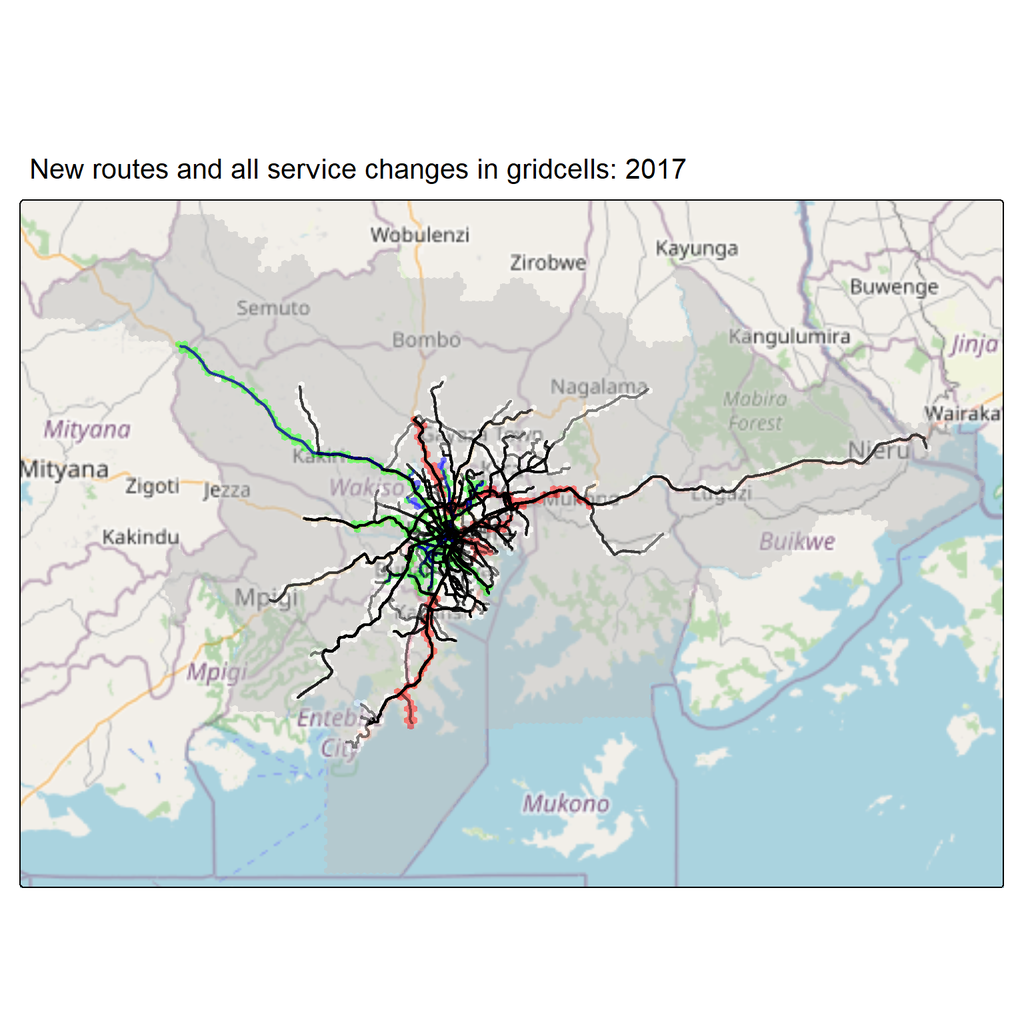

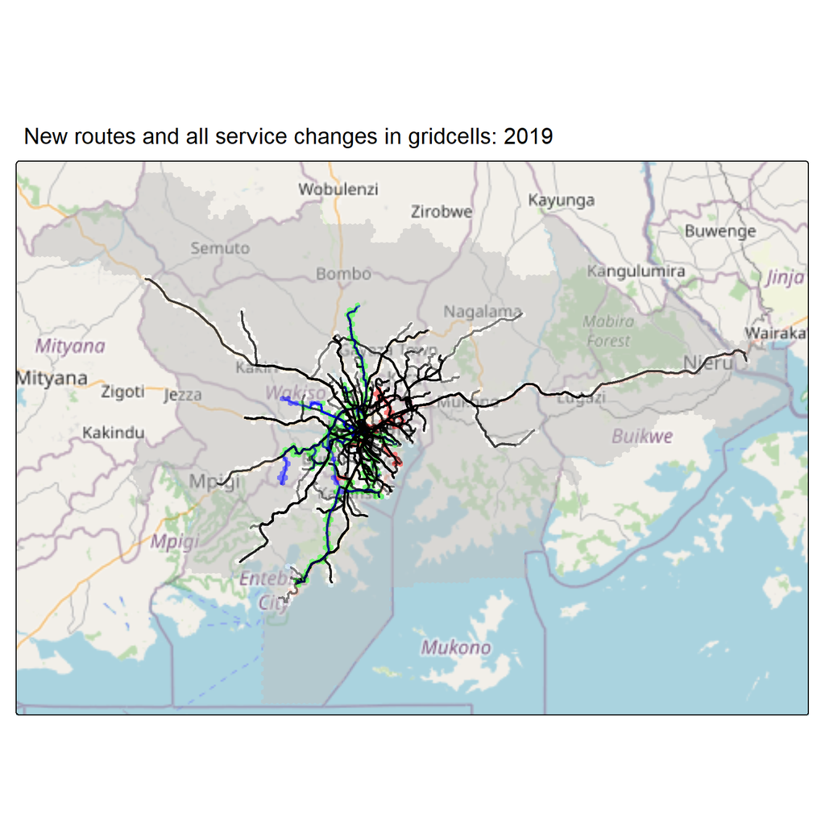